# Reviews Summary

Raimo Haikari

2022-11-25

@todo: - varmista, että olennaiset sarakkeet eivät sisällä puuttuvia arvoja!

## Arvostelut raportti

Ladataan käytettävät paketit:

```r
library(tidyverse)
```

Määritetään graafien tulostuksessa käytettäviä vakioita:

#4F424c, #B9B6B0, #FEC418, #815BA4

```r
fillColor = '#815BA4'
strokeColor = '#FEC418'
```

Luetaan tiedostot:

```r
reviews <- read_csv(str_c("../DB/", "arvostelut.csv"), na="NA")
movies <- read_csv(str_c("../DB/", "elokuvat.csv"), na="NA")
```

### Aineiston oikeellisuuden tarkastelu

Varmistetaan, että samaa kriitikkoa ei ole vahingossa tallennettu useammalla nimellä.

- yhtä criticID arvoa saa vastata ainoastaan yksi name arvo
- yhtä nimeä vastaa korkeintaan yksi criticID arvo

Periaatteessa kaimoja voi olla - ja heidät olemassa olonsa tiedetään tässä vaihessa, joten heidät tunnistaa virheellisten tupla-arvojen joukosta.

```r
distinctValues <- reviews %>%
  distinct(criticID, name, .keep_all = TRUE) %>%
  select(criticID, name)

distinctIds <- distinctValues %>%
  group_by(criticID) %>%                  # Group it by "criticID"
  summarise(Hits = n_distinct(name)) %>%  # Now summarise with unique elements per group
  filter(Hits > 1)                        # Only dublicates are included

distinctNames <- distinctValues %>%
  group_by(name) %>%
  summarise(Hits = n_distinct(criticID)) %>%
  filter(Hits > 1)
```

Päällekkäisiä id-tunnuksia löytyi:

```r
nrow(distinctIds)
```

```
## [1] 0
```

Päällekkäisiä nimiä löytyi:

```r
nrow(distinctNames)
```

```
## [1] 0
```

Tsekataan myös, esiintyykö sama arvostelu useampaan kertaan:

```r
duplicateReviews <- reviews %>%
  group_by(criticID, googleID) %>%
  mutate(num_dups = n(), dup_id = row_number()) %>%
  ungroup() %>%
  filter(num_dups > 1)
```

Päällekkäisiä arvosteluja löytyi:

```r
nrow(duplicateReviews)/2
```

```
## [1] 0
```

### Aineiston muokkaus

Lisätään elokuvat listaavaan taulukkoon tietoa, kuinka monta arvostelua kustakin elokuvasta löytyy: Selvitetään sisältääkö elokuvalista elokuvia, joista ei ole tallennettu yhtään arvostelua.

```r
numOfRevs <- apply(movies[,c('id')], 1, function(x) {length(which(reviews$googleID == x))})

movies <- movies %>% mutate(nOfReviews = numOfRevs)

# movies <- movies %>% filter(numOfRevs > 0)
```

Lisätään arvostelut sisältävään taulukkoon elokuvan nimi.

Tehdään samalla myös aputaulukko, johon on elokuvittain kerätty:

- arvostelujen lukumäärä
- arvosanojen keskiarvo
- arvosanojen mediaani

```r
namedReviews <- reviews %>%
  left_join(movies %>% filter(numOfRevs > 0), c("googleID" = "id")) %>%
  select(-link, -wiki, -imdb, -kavi, -img, -nodeJS, -nOfReviews)

reviewsSummary <- namedReviews %>%
  group_by(googleID) %>%
  summarise(ka = mean(stars), med = median(stars), n = n())
```

### Aineiston graafinen tarkastelu

#### Kerättyjen arvostelujen määrä

Tulostetaan histogrammi kuinka monta arvostelua elokuvista on tiedossa:

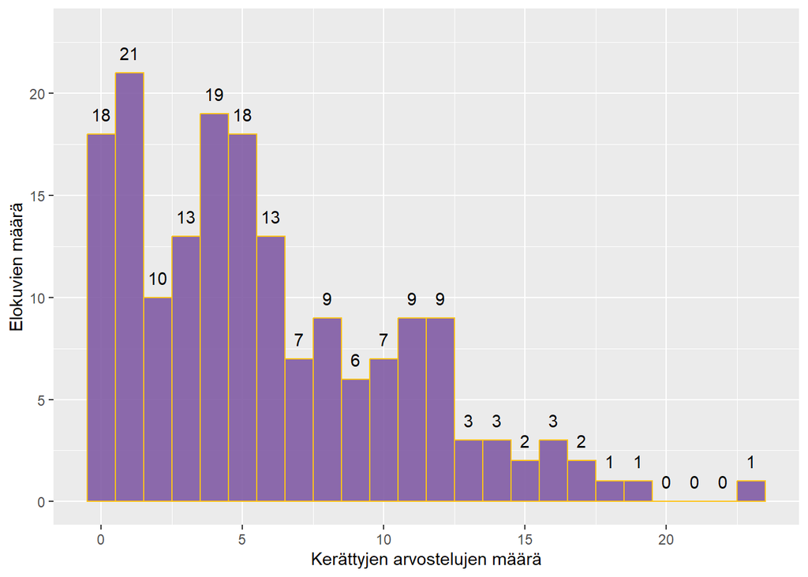

```r
movies %>%
  ggplot(aes(x = nOfReviews)) +
  stat_bin(binwidth = 1, fill=fillColor, color = strokeColor, alpha = 0.9) +
  ylim(range(movies$nOfReviews)) +
  stat_bin(binwidth=1, geom="text", aes(label=after_stat(count)), vjust=-1) +
  labs(x="Kerättyjen arvostelujen määrä", y="Elokuvien määrä")
```

Tulostetaan lista elokuvista, joista on tiedossa eniten arvosteluja.

Lisätään kuvioon myös kunkin elokuvan saamien tähtien mediaaniarvo.

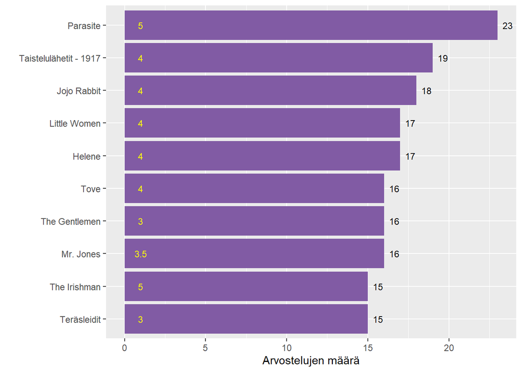

```r
reviewsSummary %>%
  top_n(10, wt = n) %>%
  left_join(movies, c("googleID" = "id")) %>%
  ggplot(aes(x=reorder(nimi, n), y= n)) +
  geom_bar(stat = 'identity', fill = fillColor) +
  coord_flip() +
  labs(x="", y = "Arvostelujen määrä") +
  geom_text(aes(label=n), hjust=-0.5, size=3) +
  geom_text(aes(label=med), y=1, size=3, col="yellow")
```

#### Arvosanojen mediaani

Tulostetaan saatujen tähtien mediaanin jakaumaa kuvaava histogrammi.

Rajataan aineistoa sen verran, että otetaan mukaan vain ne elokuvat joista on käytettävissä vähintään kolme arvostelua:

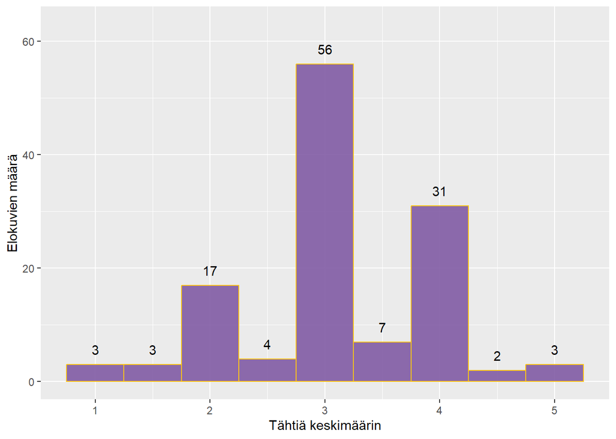

```r
# Kaikkein useimmin esiintyvän mediaaniarvosanan esiintymiskertojen määrä
yMax <- max(reviewsSummary %>% group_by(med) %>% summarise(n = n()) %>% select(n))

reviewsSummary %>%
  filter(n > 2) %>%
  ggplot(aes(med)) +
  stat_bin(binwidth = 0.5, fill=fillColor, color = strokeColor, alpha = 0.9) +
  ylim(c(0,yMax)) +
  stat_bin(binwidth=0.5, geom="text", aes(label=after_stat(count)), vjust=-1) +
  labs(x="Tähtiä keskimäärin", y="Elokuvien määrä")
```

Tulostetaan lista kriitikkoja eniten miellyttäneistä elokuvista.

Lisätään kuvioon myös tiedossa olevien arvostelujen määrä.

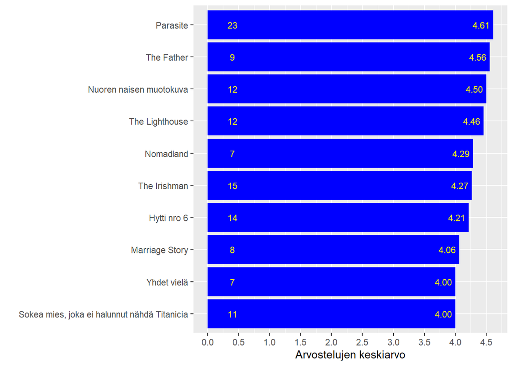

```r
reviewsSummary %>%
  filter(n > 5) %>%
  top_n(10, wt= ka) %>%
  left_join(movies, c("googleID" = "id")) %>%
  ggplot(aes(x=reorder(nimi, ka), y=ka)) +
  geom_bar(stat='identity', fill="blue") +
  coord_flip() +
  labs(x="", y="Arvostelujen keskiarvo") +
  geom_text(aes(label=format(round(ka, 2), nsmall = 2)), hjust=1.2, size=3, col="yellow") +
  scale_y_continuous(breaks=seq(0, 5, by=0.5)) +
  geom_text(aes(label=n), y=0.4, size=3, col="yellow")
```